# BIOS 699 Project 1

Mengbing Li

January 15, 2019

```r
capacity <- fread("thedata.csv")
colnames(capacity) <- tolower(colnames(capacity))
colnames(capacity)[3] <- "age"

# driver <- read.xlsx("ElderlyDriverData.xlsx", sheetName = "FeedbackReport_IE 1st Row 2014 ")
# driver[,37:38] <- NULL
# write.table(driver, file = "ElderlyDriverData.csv", quote = FALSE, sep = ",",
#             row.names = FALSE, col.names = TRUE)
driver <- fread("ElderlyDriverData.csv")
colnames(driver) <- tolower(colnames(driver))
colnames(driver)[33:34] <- c("ingresstime", "egresstime")
colnames(driver)[which(colnames(driver)=="subjective.rating..scale.from.1.to.50.")] <-
  "subjectiveRating"
```

## Exploratory Data Analysis

Things to explore:

1. bar plot of gender distribution

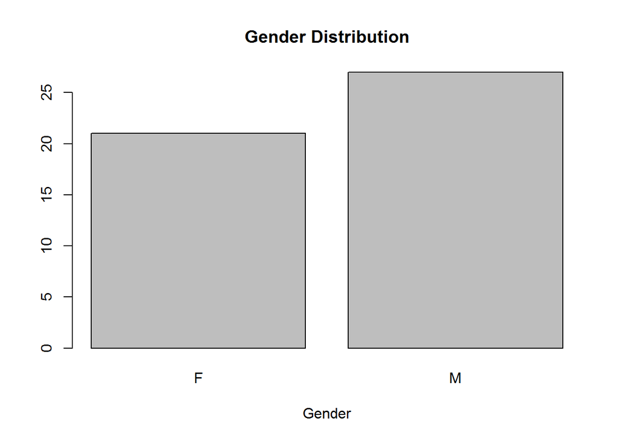

```r
counts_gender <- table(capacity$gender)
barplot(counts_gender, main="Gender Distribution",
   xlab="Gender")
```

2. histogram of age distribution

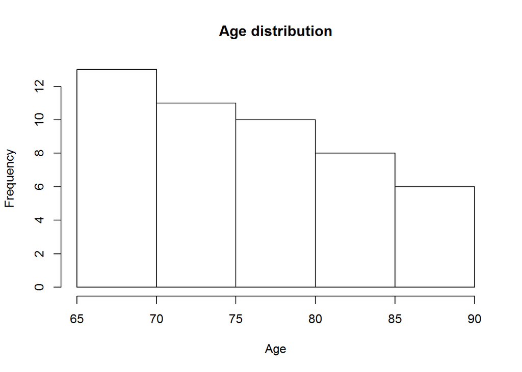

```r
hist(capacity$age, main = "Age distribution", xlab = "Age")
```

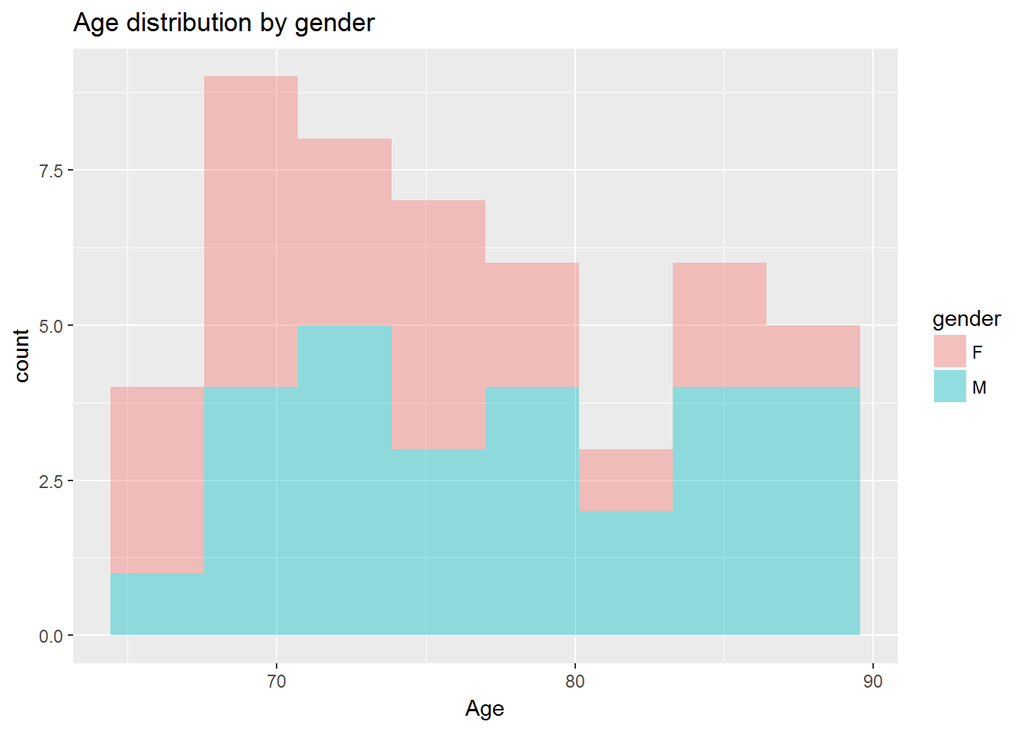

```r
ggplot(data = capacity, aes(x = age, fill = gender)) +
  geom_histogram(bins = 8, alpha = 0.4) +
  labs(title = "Age distribution by gender", x = "Age")
```

3. gender distribution by group

```r
table(capacity$gender, capacity$group)
```

```
##
##     Control Neuropathy OA
##   F      12          2  7
##   M      12         10  5
```

4. age distribution by group

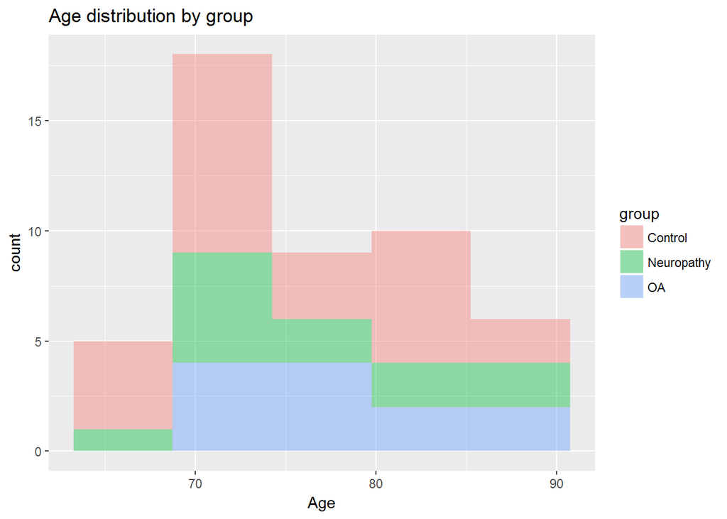

```r
ggplot(data = capacity, aes(x = age, fill = group)) +
  geom_histogram(bins = 5, alpha = 0.4) +
  labs(title = "Age distribution by group", x = "Age")
```

5. scatter plot of ingress vs egress time

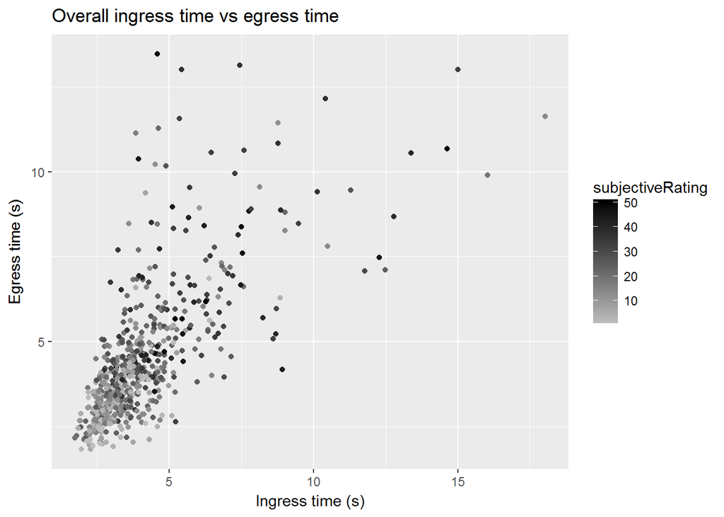

```r
ggplot(data = driver, aes(x = ingresstime, y = egresstime)) +
  geom_point(aes(color = subjectiveRating)) +
  scale_colour_gradient(low = "grey", high = "black") +
  labs(title = "Overall ingress time vs egress time",
       x = "Ingress time (s)", y = "Egress time (s)")
```

There is a positive correlation between ingress time and egress time.

Enlarge the lower-left area to see overlapping points.

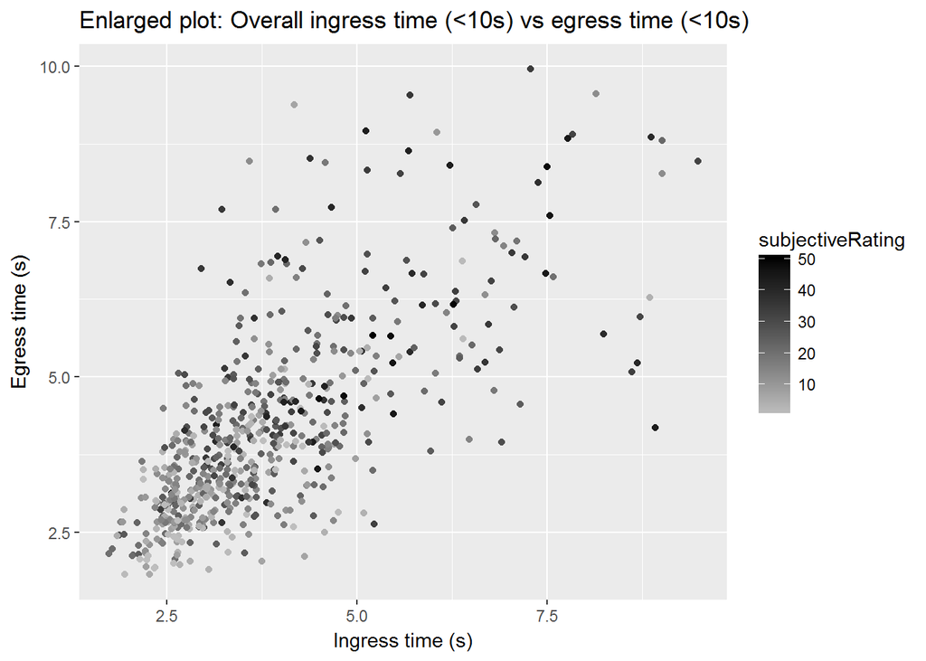

```r
ggplot(data = driver[driver$ingresstime<10 & driver$egresstime<10,], aes(x = ingresstime, y = egresstime)) +
  geom_point(aes(color = subjectiveRating)) +
  scale_colour_gradient(low = "grey", high = "black") +
  labs(title = "Enlarged plot: Overall ingress time (<10s) vs egress time (<10s)",
       x = "Ingress time (s)", y = "Egress time (s)")
```

People with longer ingress time and egress time seem to have higher subjective rating.

6. ingress and egress time by test

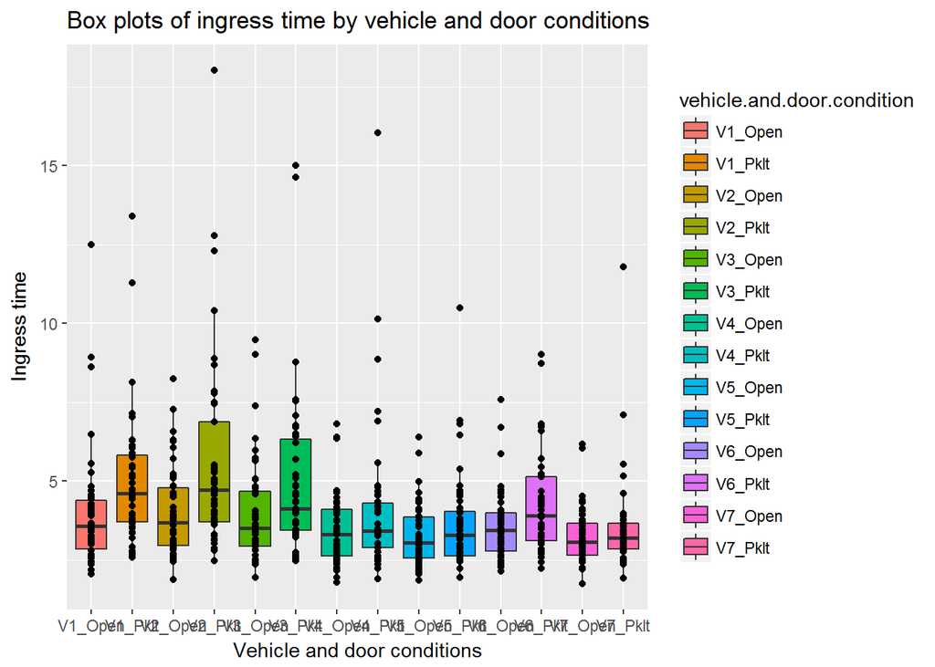

```r
ggplot(data = driver, aes(x =vehicle.and.door.condition, y = ingresstime)) +
  geom_boxplot(aes(fill = vehicle.and.door.condition)) +
  geom_point(position = position_dodge(width=0.75), aes(group = vehicle.and.door.condition)) +
  labs(title = "Box plots of ingress time by vehicle and door conditions",
       x = "Vehicle and door conditions", y = "Ingress time")
```

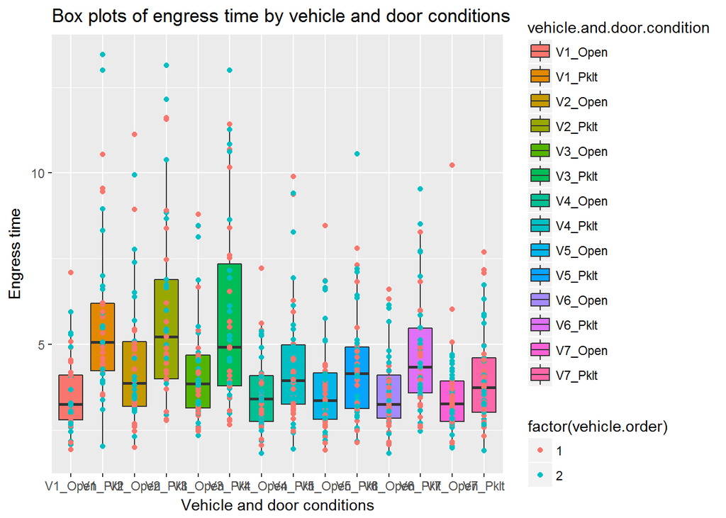

```r
ggplot(data = driver, aes(x = vehicle.and.door.condition, y = egresstime)) +
  geom_boxplot(aes(fill = vehicle.and.door.condition)) +
  geom_point(position = position_dodge(width=0.75), aes(group = vehicle.and.door.condition, color = factor(vehicle.order))) +
  labs(title = "Box plots of engress time by vehicle and door conditions",
       x = "Vehicle and door conditions", y = "Engress time")
```

The pattern of ingress time by vehicle condition and egress time by vehicle condition are similar.

Bivariate analyses of ingress time in each vehicle conditions by vehicle order

```r
vehicleConditions <- unique(driver$vehicle.and.door.condition)

bivariateIngresstime <- c()
for(name in vehicleConditions){
  fit.byVehicleCondition <- lm(data = driver[vehicle.and.door.condition == name, ], ingresstime ~ vehicle.order)
  fit.byVehicleCondition.summary <- summary(fit.byVehicleCondition)
  bivariateIngresstime <- rbind(bivariateIngresstime, fit.byVehicleCondition.summary$coefficients[2, ])
}

rownames(bivariateIngresstime) <- vehicleConditions
bivariateIngresstime
```

```
##            Estimate Std. Error    t value   Pr(>|t|)
## V1_Open -0.57521739  0.5631515 -1.0214256 0.31263626
## V1_Pklt -1.45119048  0.6082071 -2.3860137 0.02173272
## V2_Open  0.63291667  0.4110195  1.5398702 0.13075358
## V2_Pklt  0.12494048  0.9275964  0.1346927 0.89348333
## V3_Open  0.30462451  0.4944024  0.6161469 0.54104579
## V3_Pklt -0.08856522  0.8444029 -0.1048850 0.91697849
## V4_Open -0.06257246  0.3346276 -0.1869913 0.85250795
## V4_Pklt -0.08681818  0.7222658 -0.1202025 0.90486991
## V5_Open -0.08846014  0.2885117 -0.3066086 0.76055559
## V5_Pklt -0.15054348  0.4500995 -0.3344671 0.73958104
## V6_Open -0.12282609  0.3261752 -0.3765647 0.70826688
## V6_Pklt -0.38766798  0.4542491 -0.8534260 0.39815233
## V7_Open -0.12869565  0.2666566 -0.4826270 0.63175318
## V7_Pklt -0.50108696  0.4595014 -1.0905014 0.28156564
```

Bivariate analyses of egress time in each vehicle conditions by vehicle order

```r
vehicleConditions <- unique(driver$vehicle.and.door.condition)

bivariateEgresstime <- c()
for(name in vehicleConditions){
  fit.byVehicleCondition <- lm(data = driver[vehicle.and.door.condition == name, ], egresstime ~ vehicle.order)
  fit.byVehicleCondition.summary <- summary(fit.byVehicleCondition)
  bivariateEgresstime <- rbind(bivariateEgresstime, fit.byVehicleCondition.summary$coefficients[2, ])
}

rownames(bivariateEgresstime) <- vehicleConditions
bivariateEgresstime
```

```
##            Estimate Std. Error     t value  Pr(>|t|)
## V1_Open -0.09565217  0.3313919 -0.28863762 0.7742142
## V1_Pklt  0.27032468  0.7605673  0.35542506 0.7240933
## V2_Open  0.37443182  0.5912982  0.63323688 0.5298568
## V2_Pklt  1.07422619  0.7863572  1.36607913 0.1790165
## V3_Open  0.09116601  0.5063518  0.18004480 0.8579632
## V3_Pklt  0.89386957  0.8589888  1.04060677 0.3041558
## V4_Open -0.18398551  0.3252711 -0.56563746 0.5744500
## V4_Pklt  0.01064394  0.5571834  0.01910312 0.9848452
## V5_Open  0.16913043  0.4233284  0.39952534 0.6913961
## V5_Pklt  0.24735507  0.5043437  0.49044945 0.6261989
## V6_Open  0.08126812  0.3391856  0.23959781 0.8117301
## V6_Pklt  0.55000000  0.5050352  1.08903305 0.2822053
## V7_Open -0.31260870  0.3916384 -0.79820743 0.4290374
## V7_Pklt -0.03723320  0.4259015 -0.08742209 0.9307419
```

6. cross tabulation of ingress vs egress strageties

```r
table(driver$ingress.strategy, driver$egress.strategy)
```

```
##
##           normal twofeet
##   normal     258     317
##   twofeet      3      59
```

The 317 people whose ingress stragety is normal and egress stragety is two feet are worth investigating.

7. ingress time vs egress time by strageties

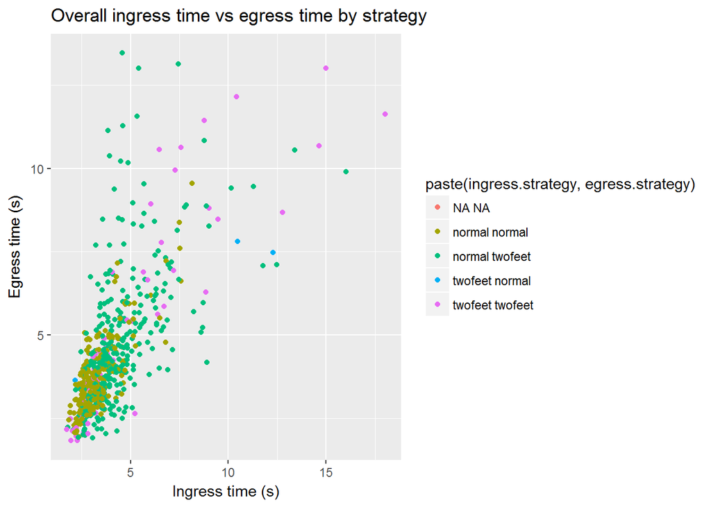

```r
ggplot(data = driver, aes(x = ingresstime, y = egresstime)) +
  geom_point(aes(color = paste(ingress.strategy, egress.strategy))) +
  # scale_colour_gradient(low = "grey", high = "black") +
  labs(title = "Overall ingress time vs egress time by strategy",
       x = "Ingress time (s)", y = "Egress time (s)")
```

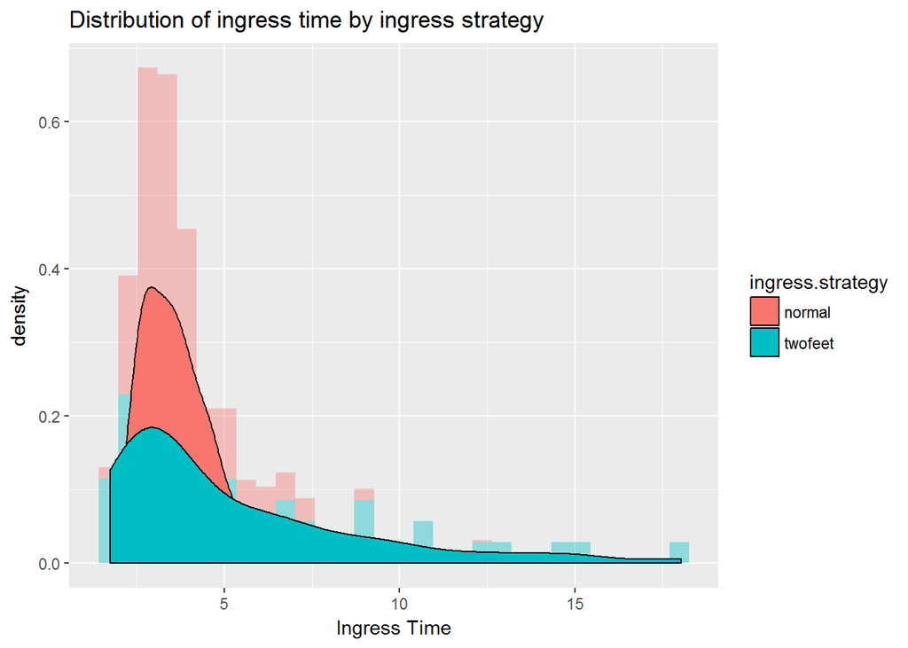

```r
ggplot(data = driver[!is.na(ingress.strategy), ], aes(x = ingresstime, fill = ingress.strategy)) +
  geom_histogram(aes(x = ingresstime,y=..density..), alpha = 0.4) +
  geom_density(aes(x = ingresstime,y=..density..)) +
  labs(title = "Distribution of ingress time by ingress strategy", x = "Ingress Time")
```